# Données sur les applications PLAY-STORE

Solène MARINIER & Fried-Junior SABAYE

# Analyse de Données

## Aperçu sur les données à étudier

| Category | Rating | Reviews | Size | Installs | Type | Price | Content.Rating | Genres | Last.Updated | Current.Ver | Android.Ver |
| --- | --- | --- | --- | --- | --- | --- | --- | --- | --- | --- | --- |
| ART_AND_DESIGN | 4.1 | 159 | 19M | 10,000+ | Free | 0 | Everyone | Art & Design | January 7, 2018 | 1.0.0 | 4.0.3 and up |
| ART_AND_DESIGN | 3.9 | 967 | 14M | 500,000+ | Free | 0 | Everyone | Art & Design;Pretend Play | January 15, 2018 | 2.0.0 | 4.0.3 and up |
| ART_AND_DESIGN | 4.7 | 87510 | 8.7M | 5,000,000+ | Free | 0 | Everyone | Art & Design | August 1, 2018 | 1.2.4 | 4.0.3 and up |
| ART_AND_DESIGN | 4.5 | 215644 | 25M | 50,000,000+ | Free | 0 | Teen | Art & Design | June 8, 2018 | Varies with device | 4.2 and up |
| ART_AND_DESIGN | 4.3 | 967 | 2.8M | 100,000+ | Free | 0 | Everyone | Art & Design;Creativity | June 20, 2018 | 1.1 | 4.4 and up |
| ART_AND_DESIGN | 4.4 | 167 | 5.6M | 50,000+ | Free | 0 | Everyone | Art & Design | March 26, 2017 | 1.0 | 2.3 and up |
| ART_AND_DESIGN | 3.8 | 178 | 19M | 50,000+ | Free | 0 | Everyone | Art & Design | April 26, 2018 | 1.1 | 4.0.3 and up |
| ART_AND_DESIGN | 4.1 | 36815 | 29M | 1,000,000+ | Free | 0 | Everyone | Art & Design | June 14, 2018 | 6.1.61.1 | 4.2 and up |
| ART_AND_DESIGN | 4.4 | 13791 | 33M | 1,000,000+ | Free | 0 | Everyone | Art & Design | September 20, 2017 | 2.9.2 | 3.0 and up |
| ART_AND_DESIGN | 4.7 | 121 | 3.1M | 10,000+ | Free | 0 | Everyone | Art & Design;Creativity | July 3, 2018 | 2.8 | 4.0.3 and up |
| ART_AND_DESIGN | 4.4 | 13880 | 28M | 1,000,000+ | Free | 0 | Everyone | Art & Design | October 27, 2017 | 1.0.4 | 4.1 and up |
| ART_AND_DESIGN | 4.4 | 8788 | 12M | 1,000,000+ | Free | 0 | Everyone | Art & Design | July 31, 2018 | 1.0.15 | 4.0 and up |
| ART_AND_DESIGN | 4.2 | 44829 | 20M | 10,000,000+ | Free | 0 | Teen | Art & Design | April 2, 2018 | 3.8 | 4.1 and up |
| ART_AND_DESIGN | 4.6 | 4326 | 21M | 100,000+ | Free | 0 | Everyone | Art & Design | June 26, 2018 | 1.0.4 | 4.4 and up |
| ART_AND_DESIGN | 4.4 | 1518 | 37M | 100,000+ | Free | 0 | Everyone | Art & Design | August 3, 2018 | 1.2.3 | 2.3 and up |
| ART_AND_DESIGN | 3.2 | 55 | 2.7M | 5,000+ | Free | 0 | Everyone | Art & Design | June 6, 2018 | NaN | 4.2 and up |
| ART_AND_DESIGN | 4.7 | 3632 | 5.5M | 500,000+ | Free | 0 | Everyone | Art & Design | July 31, 2018 | 3.1 | 4.1 and up |
| ART_AND_DESIGN | 4.5 | 27 | 17M | 10,000+ | Free | 0 | Everyone | Art & Design | November 7, 2017 | 1.0 | 2.3 and up |
| ART_AND_DESIGN | 4.3 | 194216 | 39M | 5,000,000+ | Free | 0 | Everyone | Art & Design | August 3, 2018 | 2.2.5 | 4.0.3 and up |
| ART_AND_DESIGN | 4.6 | 224399 | 31M | 10,000,000+ | Free | 0 | Everyone | Art & Design | July 30, 2018 | 5.5.4 | 4.1 and up |
| ART_AND_DESIGN | 4.0 | 450 | 14M | 100,000+ | Free | 0 | Everyone | Art & Design | April 20, 2018 | 4.0 | 4.1 and up |
| ART_AND_DESIGN | 4.1 | 654 | 12M | 100,000+ | Free | 0 | Everyone | Art & Design | March 20, 2018 | 1.1 | 4.0.3 and up |
| ART_AND_DESIGN | 4.7 | 7699 | 4.2M | 500,000+ | Free | 0 | Everyone 10+ | Art & Design | July 12, 2018 | 2.2.6.2 | 4.0.3 and up |
| ART_AND_DESIGN | NaN | 61 | 7.0M | 100,000+ | Free | 0 | Everyone | Art & Design;Action & Adventure | March 7, 2018 | 1.0.0 | 4.1 and up |
| ART_AND_DESIGN | 4.7 | 118 | 23M | 50,000+ | Free | 0 | Everyone | Art & Design | July 7, 2018 | 1.1.3 | 4.1 and up |
| ART_AND_DESIGN | 4.8 | 192 | 6.0M | 10,000+ | Free | 0 | Everyone | Art & Design | April 25, 2018 | 1.5 | 3.0 and up |
| ART_AND_DESIGN | 4.7 | 20260 | 25M | 500,000+ | Free | 0 | Everyone | Art & Design;Creativity | October 11, 2017 | 1.0.8 | 4.0.3 and up |
| ART_AND_DESIGN | 4.1 | 203 | 6.1M | 100,000+ | Free | 0 | Everyone | Art & Design | March 21, 2018 | 1.03 | 4.0.3 and up |
| ART_AND_DESIGN | 3.9 | 136 | 4.6M | 10,000+ | Free | 0 | Everyone | Art & Design | July 12, 2018 | 6.0 | 2.3 and up |
| ART_AND_DESIGN | 4.1 | 223 | 4.2M | 100,000+ | Free | 0 | Everyone | Art & Design | August 22, 2017 | 1.0 | 2.3 and up |

# Analyse des catégories des applications

## Observations portées sur les effectifs

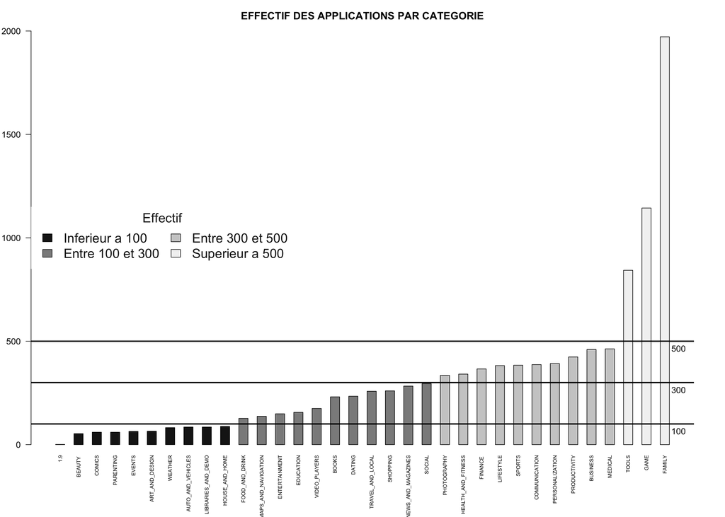

Sur ce graphique, on représente l’effectif des applications pour chaque catégorie. On ajoute des lignes horizontales à hauteur d’effectif, h=100, h=300 et h=500 pour séparer les catégories en 4 groupes en fonction du nombre d’applications qu’elles possèdent. Notons qu’à chacun de ces groupes, est associée une couleur distincte.

## Zoom sur les catégories

### Classement par groupes d’effectifs

|  | EFFECTIF | PROPORTION (%) | Nombre appliS Payantes |
| --- | --- | --- | --- |
| **Groupe 1 : Inferieur a 100** |  |  |  |
| 1.9 | 1 | 0.009 | 0 |
| BEAUTY | 53 | 0.489 | 0 |
| COMICS | 60 | 0.553 | 0 |
| PARENTING | 60 | 0.553 | 2 |
| EVENTS | 64 | 0.590 | 1 |
| ART_AND_DESIGN | 65 | 0.600 | 3 |
| WEATHER | 82 | 0.756 | 8 |
| AUTO_AND_VEHICLES | 85 | 0.784 | 3 |
| LIBRARIES_AND_DEMO | 85 | 0.784 | 1 |
| HOUSE_AND_HOME | 88 | 0.812 | 0 |
| **Groupe 2 : Entre 100 et 300** |  |  |  |
| FOOD_AND_DRINK | 127 | 1.171 | 2 |
| MAPS_AND_NAVIGATION | 137 | 1.264 | 5 |
| ENTERTAINMENT | 149 | 1.374 | 2 |
| EDUCATION | 156 | 1.439 | 4 |
| VIDEO_PLAYERS | 175 | 1.614 | 4 |
| BOOKS_AND_REFERENCE | 231 | 2.131 | 28 |
| DATING | 234 | 2.158 | 7 |
| TRAVEL_AND_LOCAL | 258 | 2.380 | 12 |
| SHOPPING | 260 | 2.398 | 2 |
| NEWS_AND_MAGAZINES | 283 | 2.610 | 2 |
| SOCIAL | 295 | 2.721 | 3 |
| **Groupe 3 : Entre 300 ET 500** |  |  |  |
| PHOTOGRAPHY | 335 | 3.090 | 22 |
| HEALTH_AND_FITNESS | 341 | 3.145 | 16 |
| FINANCE | 366 | 3.376 | 17 |
| LIFESTYLE | 382 | 3.524 | 19 |
| SPORTS | 384 | 3.542 | 24 |
| COMMUNICATION | 387 | 3.570 | 27 |
| PERSONALIZATION | 392 | 3.616 | 83 |
| PRODUCTIVITY | 424 | 3.911 | 28 |
| BUSINESS | 460 | 4.243 | 14 |
| MEDICAL | 463 | 4.271 | 109 |
| **Groupe 4 : Superieur A 500** |  |  |  |
| TOOLS | 843 | 7.776 | 78 |
| GAME | 1144 | 10.553 | 83 |
| FAMILY | 1972 | 18.190 | 191 |

### Représentations graphiques associées aux différents groupes

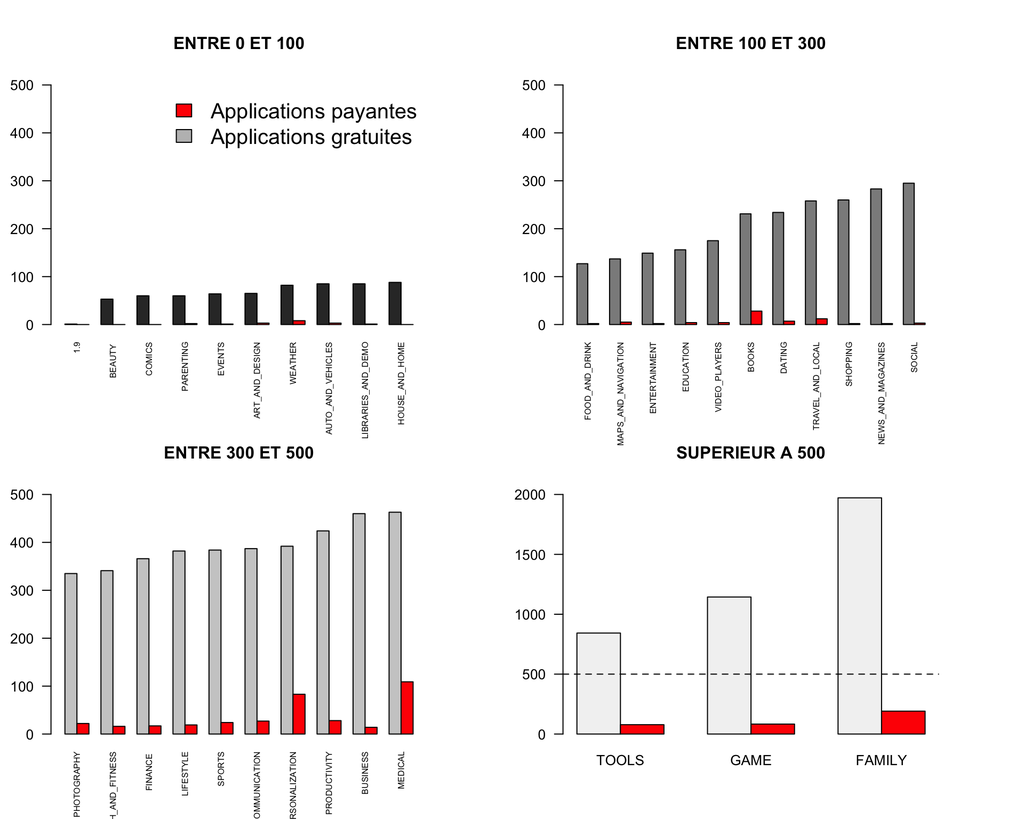

## Relation entre les différents effectifs

L’objectif de cette représentation graphique est de savoir si le nombre d’applications payantes par catégorie augmente avec le nombre d’applications, toutes confondues.

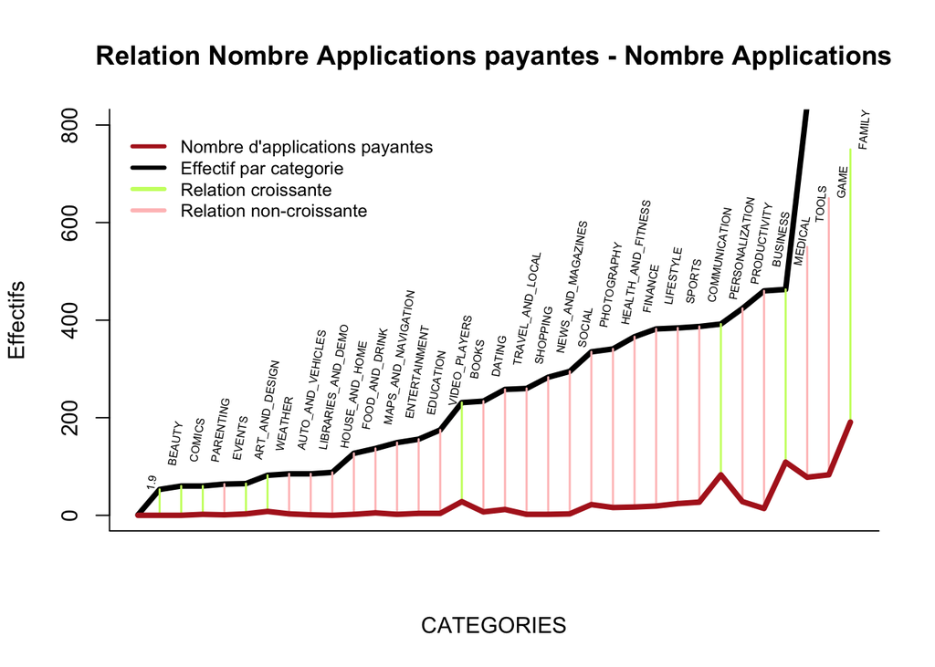

On a ordonné les catégories par ordre croissant de leur effectifs.

On parle de relation croissante lorsque l’effectif d’applications payantes de la catégorie est supérieur à l’effectif d’applications payantes de toutes les catégories précédentes. On constate, pour 25 des 34 catégories, que cette relation de croissance n’est pas vérifiée.

On peut donc conclure que le nombre d’applications payantes par catégorie ne dépend de l’effectif de celle-ci.

# Analyse des notes des applications

## Moyennes des notes par catégorie

|  | Moyennes globales | Moyennes appliS gratuites | Moyenne appliS payantes |
| --- | --- | --- | --- |
| ART_AND_DESIGN | 4.358065 | 4.338983 | 4.733333 |
| AUTO_AND_VEHICLES | 4.190411 | 4.184722 | 4.600000 |
| BEAUTY | 4.278571 | 4.278571 | 0.000000 |
| BOOKS_AND_REFERENCE | 4.346067 | 4.349412 | 4.275000 |
| BUSINESS | 4.121452 | 4.118493 | 4.200000 |
| COMICS | 4.155172 | 4.155172 | 0.000000 |
| COMMUNICATION | 4.158537 | 4.165359 | 4.063636 |
| DATING | 3.970769 | 3.978010 | 3.625000 |
| EDUCATION | 4.389032 | 4.379470 | 4.750000 |
| ENTERTAINMENT | 4.126174 | 4.119728 | 4.600000 |
| EVENTS | 4.435556 | 4.435556 | 0.000000 |
| FAMILY | 4.192272 | 4.181767 | 4.295062 |
| FINANCE | 4.131889 | 4.144516 | 3.830769 |
| FOOD_AND_DRINK | 4.166972 | 4.163551 | 4.350000 |
| GAME | 4.286326 | 4.279804 | 4.372727 |
| HEALTH_AND_FITNESS | 4.277104 | 4.272281 | 4.391667 |
| HOUSE_AND_HOME | 4.197368 | 4.197368 | 0.000000 |
| LIBRARIES_AND_DEMO | 4.178462 | 4.178462 | 0.000000 |
| LIFESTYLE | 4.094904 | 4.085473 | 4.250000 |
| MAPS_AND_NAVIGATION | 4.051613 | 4.059664 | 3.860000 |
| MEDICAL | 4.189143 | 4.165649 | 4.259091 |
| NEWS_AND_MAGAZINES | 4.132189 | 4.126407 | 4.800000 |
| PARENTING | 4.300000 | 4.339583 | 3.350000 |
| PERSONALIZATION | 4.335987 | 4.307287 | 4.441791 |
| PHOTOGRAPHY | 4.192114 | 4.201003 | 4.044444 |
| PRODUCTIVITY | 4.211396 | 4.211712 | 4.205556 |
| SHOPPING | 4.259664 | 4.257627 | 4.500000 |
| SOCIAL | 4.255598 | 4.259922 | 3.700000 |
| SPORTS | 4.223511 | 4.221212 | 4.254545 |
| TOOLS | 4.047411 | 4.035917 | 4.169841 |
| TRAVEL_AND_LOCAL | 4.109292 | 4.109633 | 4.100000 |
| VIDEO_PLAYERS | 4.063750 | 4.062821 | 4.100000 |
| WEATHER | 4.244000 | 4.230882 | 4.371429 |

Les lignes colorées sont celles des catégories qui n’ont aucune application payante.

## Relation entre les moyennes des notes

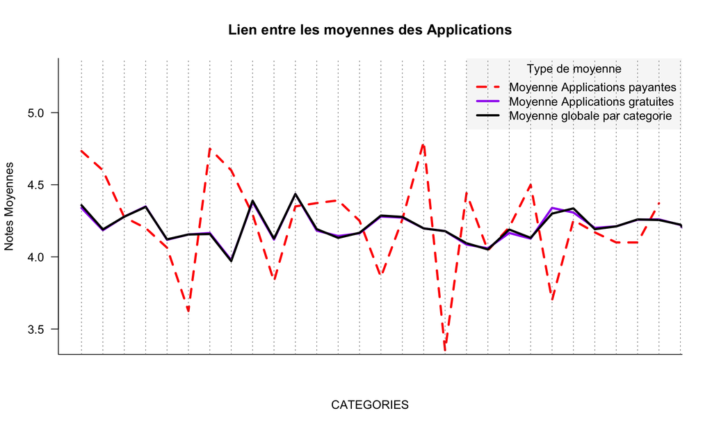

On peut constater que les fortes fluctuations des moyennes des applications payantes n’ont pratiquement aucun impact sur les moyennes générales. Ceci est dû à la différence significative d’effectifs entre les applications payantes et les applications gratuites dans toutes les catégories.

## Représentation graphique

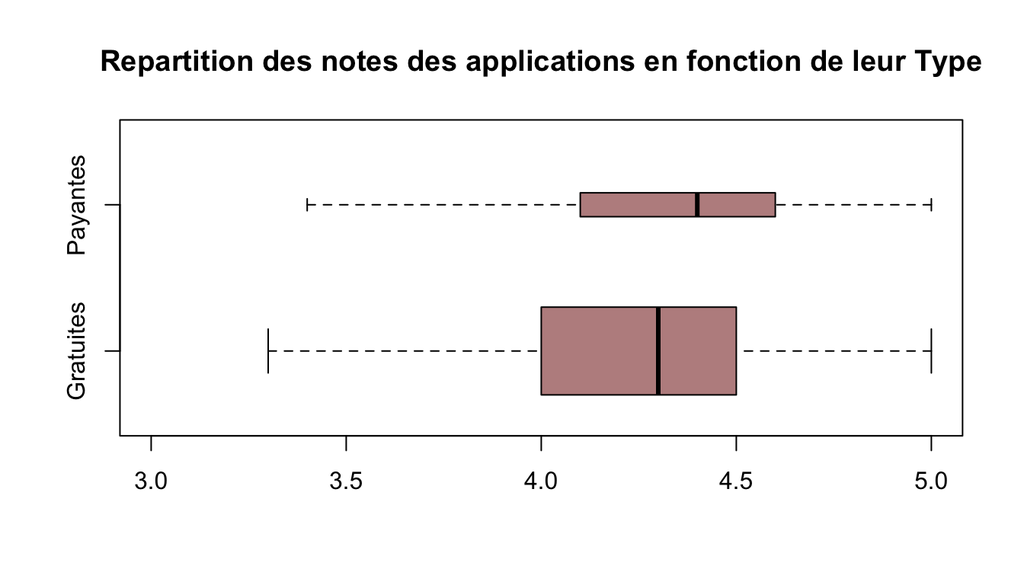

|  | Gratuites | Payantes |
| --- | --- | --- |
| Min | 3.3 | 3.4 |
| Q1 | 4.0 | 4.1 |
| Mediane | 4.3 | 4.4 |
| Q3 | 4.5 | 4.6 |
| Max | 5.0 | 5.0 |

## Test sur les moyennes

On effectue un test pour savoir si la moyenne des notes des applications payantes est supérieure à la moyenne des notes des applications gratuites.

**H0 :** La moyenne des notes pour les applications payantes est égale à la moyenne des notes pour les applications gratuites.

**H1 :** La moyenne des notes pour les applications payante est supérieure à la moyenne des notes pour les applications gratuites.

|  | Note |
| --- | --- |
| Moyenne pour les payantes | 4.2666151 |
| Moyenne pour les gratuites | 4.1862025 |
| Borne inf. de l’IC 95% de la diff. | 0.0438281 |
| Borne sup. de l’IC 95% de la diff. | Inf |
| p-value | 0.0001575 |

La p-value est inférieure à 0.05, donc au risque 5%, on rejette H0. Donc, au risque 5%, la moyenne des notes des applications payantes est supérieure à la moyenne des notes des applications gratuites.